# Best Practices

Savet Hong

Apr 19, 2018

# File Structure

## Folders

- Folders/Directories should be organized in a manner that’s easy to
  - follow and identify content
  - replicate
- Project Folder should include the following subfolders:
  - Script
  - Original Data
  - Modified (or Analysis) Data
  - Results
  - README
- Principle: Should be able to provide the README, Script, and Original Data to someone and everything else in the project folder can be reproduced.
  - README should outline project, source of data, order of script files, and product generated.
- Additional Reading: Project TIER (https://www.projecttier.org/documents/3/TIER-Protocol-2.0-for-R.pdf)

# Script Structure

## Script

- Layout includes:
  - Preamble
  - Libraries/ Import
  - Data Setup
  - Analysis
  - Graphics/Tables
  - Export

## Preamble

- Title/Project
- Author (optional)
- Purpose of Script File
- Previous Dependent Script File
- Subsequent Dependent Script File
- Notes

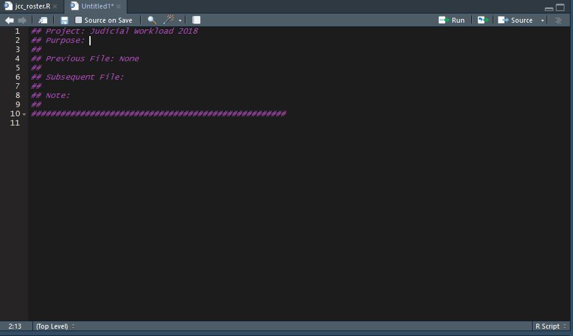

## Libraries/Import

- include major libraries used for file to run
  - allow others to know what packages they need to install to use your code
- import all data to be used in one section
  - shows other user all relevant data file necessary for analysis or code functionality

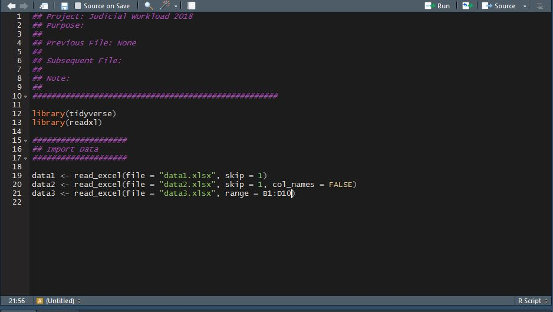

## Data Setup

- Any data cleaning or restructuring necessary for data use
- May include subsection to allow readers to understand what is done for which data

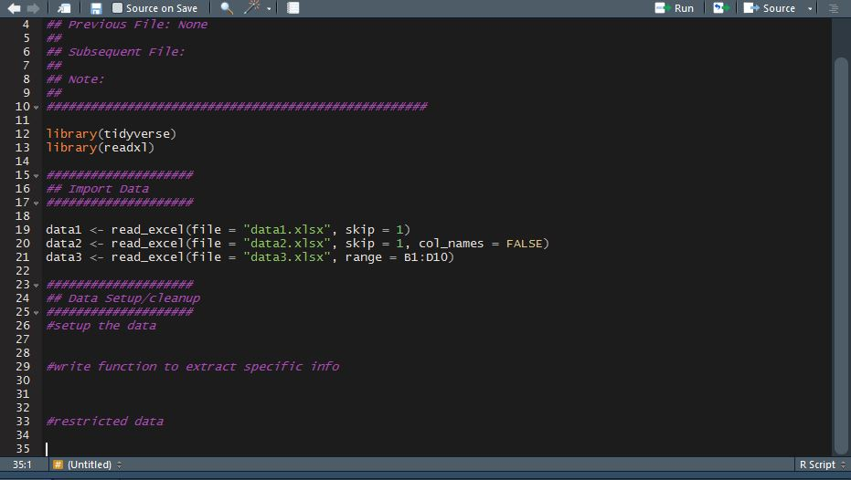

## Analysis

- Include comments on the type of analysis or calculation being performed
  - if the calculation is for a specific table, name the table
  - e.g., Table 1 in CSR

## Graphics/Tables

- Include comments on the type graphs being generated
  - include figure name if used in specific report
  - e.g., Figure 1 for Council Report

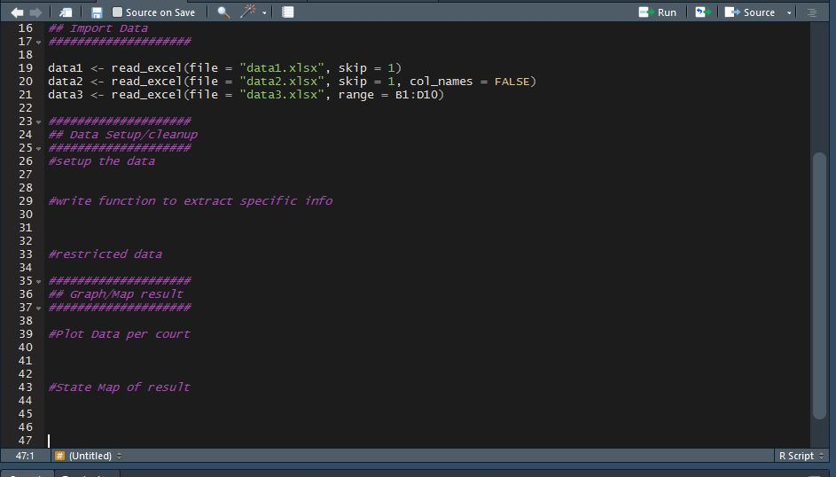

## Save/Export

- Identify the data objects being saved or exported for later use

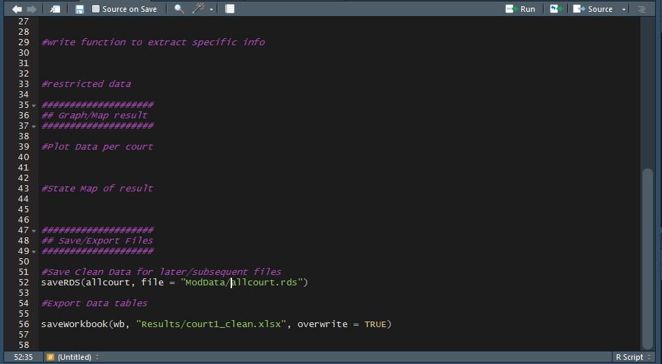

# Syntax Structure

## Spacing

- Spaces around assigment and operators
  - Includes: <-, ->, +, -, =, ==, &, &&, etc.
- Space only after comma (not before)
- Extra space for alignment
- Space before left parentheses except in a call function

  ```r
  basic  <- list(
    total = a + b + c,
    mean  = (a + b + c) / n)
  ```

## Curly Braces

- opening curly brace ( { ) should never go on its own line
- always followed by a new line
- closing curly brace ( } ) should always go on its own line

  ```r
  if (y < 0 & debug) {
    message(“Y is negative”)
  }
  ```

## Indentation

- Be consistent
- Use two spaces or tab
- Don’t mix spaces and tab

## Line Length

- 80 characters
- Within the viewing frame

## Concepts covered

1. Folder structure
2. Script formatting
3. Syntax formatting

## References

- Google’s R Style Guide https://google.github.io/styleguide/Rguide.xml
- Hadley Wickham’s Advance http://adv-r.had.co.nz/Style.html
- Tidyverse Style Guide http://style.tidyverse.org/syntax.html#semicolons